# Week 12 IP

Njoki Mbugua

7/1/2021

```r
library(knitr)
```

```r
knitr::opts_chunk$set(echo = TRUE)
```

## 1. Defining the Question

### a) Specifying the Question

The main objective of this project is to determine which individuals are most likely to click on ads in a blog post.

### b) Defining the Metric for Success

Exhaustively perform Exploratory Data Analysis (Univariate and bivariate analysis) to determine that enabling factors of individuals clicking on ads.

### c) Understanding the context

Working as a consultant Data science consultant to help the client identify which individuals are most likely to click on her ads. The entrepreneur has created an online cryptography course and would want to advertise it on her blog. She currently targets audiences originating from various countries. In the past, she ran ads to advertise a related course on the same blog and collected data in the process.

### d) Recording the experimental design

Importing and reading the data Data Cleaning Exploratory Data Analysis(Univariate and bivariate) Conclusions and recommendations

### e) Data Relevance

The data columns in the data set include:Daily Time Spent on Site,Age,Area Income,Daily Internet Usage,Ad Topic Line,City,Male,Country,Time stamp and Clicked on Ad(http://bit.ly/IPAdvertisingData).

# Reading the data

```r
data <- read.csv(file.choose(),na.strings = "")

# printing the top six rows of the dataset
head(data)
```

```
##   Daily.Time.Spent.on.Site Age Area.Income Daily.Internet.Usage
## 1                    68.95  35    61833.90               256.09
## 2                    80.23  31    68441.85               193.77
## 3                    69.47  26    59785.94               236.50
## 4                    74.15  29    54806.18               245.89
## 5                    68.37  35    73889.99               225.58
## 6                    59.99  23    59761.56               226.74
##                           Ad.Topic.Line           City Male    Country
## 1    Cloned 5thgeneration orchestration    Wrightburgh    0    Tunisia
## 2    Monitored national standardization      West Jodi    1      Nauru
## 3      Organic bottom-line service-desk       Davidton    0 San Marino
## 4 Triple-buffered reciprocal time-frame West Terrifurt    1      Italy
## 5         Robust logistical utilization   South Manuel    0    Iceland
## 6       Sharable client-driven software      Jamieberg    1     Norway
##         Timestamp Clicked.on.Ad
## 1  3/27/2016 0:53             0
## 2   4/4/2016 1:39             0
## 3 3/13/2016 20:35             0
## 4  1/10/2016 2:31             0
## 5   6/3/2016 3:36             0
## 6 5/19/2016 14:30             0
```

```r
# printing the bottom rows of the dataset

tail(data, n=10)
```

```
##      Daily.Time.Spent.on.Site Age Area.Income Daily.Internet.Usage
## 991                     35.79  44    33813.08               165.62
## 992                     38.96  38    36497.22               140.67
## 993                     69.17  40    66193.81               123.62
## 994                     64.20  27    66200.96               227.63
## 995                     43.70  28    63126.96               173.01
## 996                     72.97  30    71384.57               208.58
## 997                     51.30  45    67782.17               134.42
## 998                     51.63  51    42415.72               120.37
## 999                     55.55  19    41920.79               187.95
## 1000                    45.01  26    29875.80               178.35
##                               Ad.Topic.Line          City Male
## 991          Enterprise-wide tangible model   North Katie    1
## 992  Versatile mission-critical application   Mauricefurt    1
## 993           Extended leadingedge solution   New Patrick    0
```

[output cut: 18 more lines]

```r
# checking the number of rows in the dataset
nrow(data)
```

```
## [1] 1000
```

```r
#We have 1000 rows.
```

```r
# checking the number of columns
ncol(data)
```

```
## [1] 10
```

```r
#The dataset has 10 columns
```

```r
# checking structure of the dataset
str(data)
```

```
## 'data.frame':    1000 obs. of  10 variables:
##  $ Daily.Time.Spent.on.Site: num  69 80.2 69.5 74.2 68.4 ...
##  $ Age                     : int  35 31 26 29 35 23 33 48 30 20 ...
##  $ Area.Income             : num  61834 68442 59786 54806 73890 ...
##  $ Daily.Internet.Usage    : num  256 194 236 246 226 ...
##  $ Ad.Topic.Line           : chr  "Cloned 5thgeneration orchestration" "Monitored national standardization" "Organic bottom-line service-desk" "Triple-buffered reciprocal time-frame" ...
##  $ City                    : chr  "Wrightburgh" "West Jodi" "Davidton" "West Terrifurt" ...
##  $ Male                    : int  0 1 0 1 0 1 0 1 1 1 ...
##  $ Country                 : chr  "Tunisia" "Nauru" "San Marino" "Italy" ...
##  $ Timestamp               : chr  "3/27/2016 0:53" "4/4/2016 1:39" "3/13/2016 20:35" "1/10/2016 2:31" ...
##  $ Clicked.on.Ad           : int  0 0 0 0 0 0 0 1 0 0 ...
```

```r
# getting summary on the columns
summary(data)
```

```
##  Daily.Time.Spent.on.Site      Age         Area.Income    Daily.Internet.Usage
##  Min.   :32.60            Min.   :19.00   Min.   :13996   Min.   :104.8
##  1st Qu.:51.36            1st Qu.:29.00   1st Qu.:47032   1st Qu.:138.8
##  Median :68.22            Median :35.00   Median :57012   Median :183.1
##  Mean   :65.00            Mean   :36.01   Mean   :55000   Mean   :180.0
##  3rd Qu.:78.55            3rd Qu.:42.00   3rd Qu.:65471   3rd Qu.:218.8
##  Max.   :91.43            Max.   :61.00   Max.   :79485   Max.   :270.0
##  Ad.Topic.Line          City                Male         Country
##  Length:1000        Length:1000        Min.   :0.000   Length:1000
##  Class :character   Class :character   1st Qu.:0.000   Class :character
##  Mode  :character   Mode  :character   Median :0.000   Mode  :character
##                                        Mean   :0.481
##                                        3rd Qu.:1.000
##                                        Max.   :1.000
##   Timestamp         Clicked.on.Ad
##  Length:1000        Min.   :0.0
##  Class :character   1st Qu.:0.0
##  Mode  :character   Median :0.5
##                     Mean   :0.5
##                     3rd Qu.:1.0
##                     Max.   :1.0
```

# Data Cleaning

## Checking for missing values

```r
sum(is.na(data))
```

```
## [1] 0
```

There are no missing values in the data set.

## Checking for duplicates

```r
# duplicated(data)
sum(duplicated(data))
```

```
## [1] 0
```

```r
# there are no duplicates in the dataset
```

There are no duplicates in the data set.

```r
install.packages("tidyverse", repos = 'http://cran.us.r-project.org')
library(tidyverse)
library(dplyr)
```

```r
# Selecting numeric column
df <- select_if(data, is.numeric)
df
```

```
##      Daily.Time.Spent.on.Site Age Area.Income Daily.Internet.Usage Male
## 1                       68.95  35    61833.90               256.09    0
## 2                       80.23  31    68441.85               193.77    1
## 3                       69.47  26    59785.94               236.50    0
## 4                       74.15  29    54806.18               245.89    1
## 5                       68.37  35    73889.99               225.58    0
## 6                       59.99  23    59761.56               226.74    1
## 7                       88.91  33    53852.85               208.36    0
## 8                       66.00  48    24593.33               131.76    1
## 9                       74.53  30    68862.00               221.51    1
## 10                      69.88  20    55642.32               183.82    1
## 11                      47.64  49    45632.51               122.02    0
## 12                      83.07  37    62491.01               230.87    1
## 13                      69.57  48    51636.92               113.12    1
## 14                      79.52  24    51739.63               214.23    0
```

[output cut: 1987 more lines]

## Checking for outliers

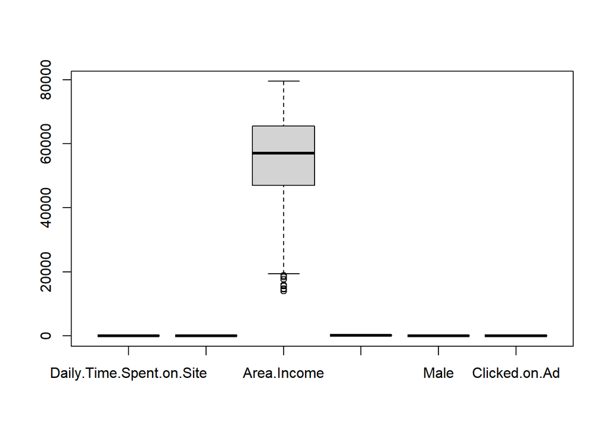

```r
# Using the boxplot to detect outliers in the numeric columns
boxplot(df)
```

Outliers were detected in the income column.

Listing the outliers in the income column

```r
# listing outliers
boxplot.stats(df$Area.Income)$out
```

```
## [1] 17709.98 18819.34 15598.29 15879.10 14548.06 13996.50 14775.50 18368.57
```

The outliers were not removed since income levels vary extremely meaning that they are valid and important for analysis.

# Univariate analysis

## Measures of central tendency

```r
# Time spent on site
Daily.Time.Spent.on.Site.mean <- mean(data$Daily.Time.Spent.on.Site)
Daily.Time.Spent.on.Site.mean
```

```
## [1] 65.0002
```

```r
Daily.Time.Spent.on.Site.median <-median(data$Daily.Time.Spent.on.Site)
Daily.Time.Spent.on.Site.median
```

```
## [1] 68.215
```

```r
Daily.Time.Spent.on.Site.sd <- sd(data$Daily.Time.Spent.on.Site)
Daily.Time.Spent.on.Site.sd
```

```
## [1] 15.85361
```

The mean daily time spent on site is 65.002

```r
# Income mean
##Area.Income.mean
```

The mean income is 55000.

```r
# Average age
##Age.mean
```

The average age is 36.

```r
# getting summary statistics for numeric variables
summary(df)
```

```
##  Daily.Time.Spent.on.Site      Age         Area.Income    Daily.Internet.Usage
##  Min.   :32.60            Min.   :19.00   Min.   :13996   Min.   :104.8
##  1st Qu.:51.36            1st Qu.:29.00   1st Qu.:47032   1st Qu.:138.8
##  Median :68.22            Median :35.00   Median :57012   Median :183.1
##  Mean   :65.00            Mean   :36.01   Mean   :55000   Mean   :180.0
##  3rd Qu.:78.55            3rd Qu.:42.00   3rd Qu.:65471   3rd Qu.:218.8
##  Max.   :91.43            Max.   :61.00   Max.   :79485   Max.   :270.0
##       Male       Clicked.on.Ad
##  Min.   :0.000   Min.   :0.0
##  1st Qu.:0.000   1st Qu.:0.0
##  Median :0.000   Median :0.5
##  Mean   :0.481   Mean   :0.5
##  3rd Qu.:1.000   3rd Qu.:1.0
##  Max.   :1.000   Max.   :1.0
```

The mean age of people visiting the site is 36, max age is 61 and min age is 19.

The maximum area income is 79485 and min area income is 13996 with mean area income being 55000.

The minimum amount of time spent on the blog is 32.60 and maximum is 91.43 with a mean of 65.

The maximum daily internet usage on the website is 270 with a mean of 180 and a minimum of 104.

```r
install.packages("moments", repos = 'http://cran.us.r-project.org')
library(moments)
```

```r
install.packages("ggplot2", repos = 'http://cran.us.r-project.org')
library(ggplot2)
```

## Univariate graphical EDA

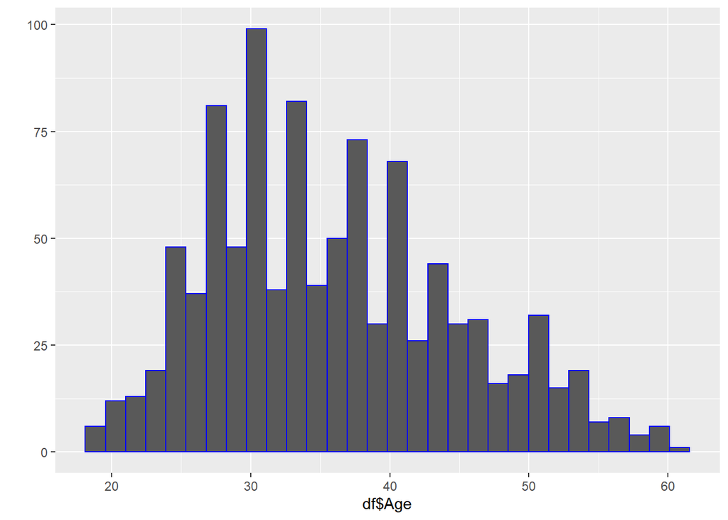

```r
#help("ggplot2")
# Histogram of age.
qplot(data=df, x=df$Age, colour=I("blue"))
```

Age is not normally distributed. Most of the respondents are between the ages of 25 and 50.

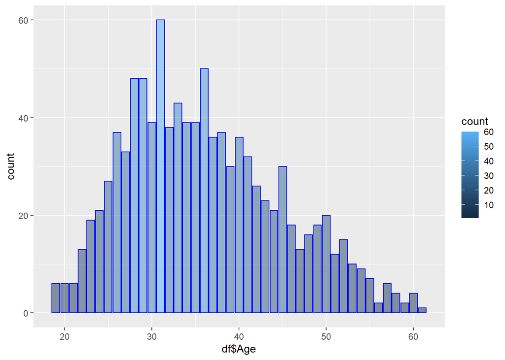

```r
#library(ggplot2)
ggplot(data=df, aes(x = df$Age)) +
    geom_bar(aes(fill=..count..), alpha=0.5, size=0.5,colour="blue",binwidth=60*5)
```

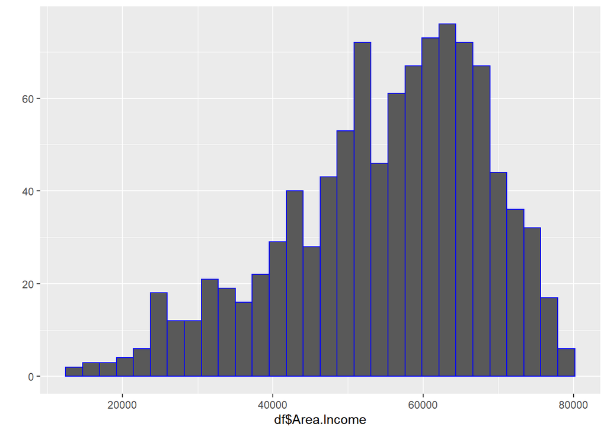

```r
# Histogram of Area income
qplot(data=df, x=df$Area.Income, colour=I("blue"))
```

Most People were earning between 50,000 and 70,000.

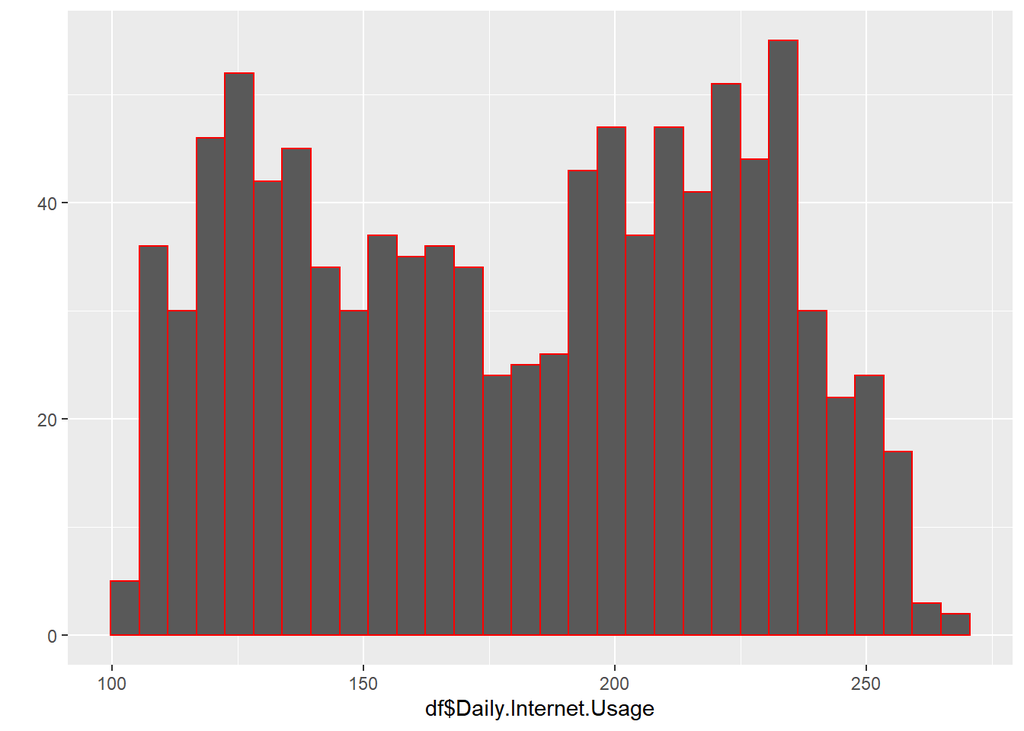

```r
# Histogram of Daily Internet Usage
qplot(data=df, x=df$Daily.Internet.Usage, colour=I("red"))
```

There is no particular pattern for the daily internet usage

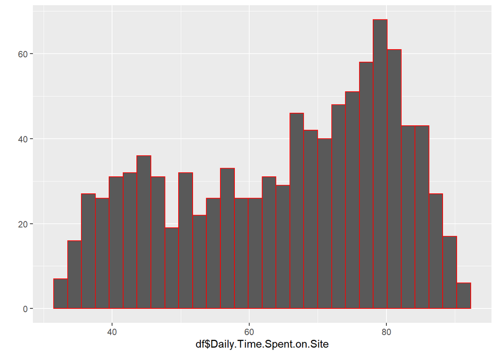

```r
qplot(data=df, x=df$Daily.Time.Spent.on.Site, colour=I("red"))
```

# Bivariate Analysis

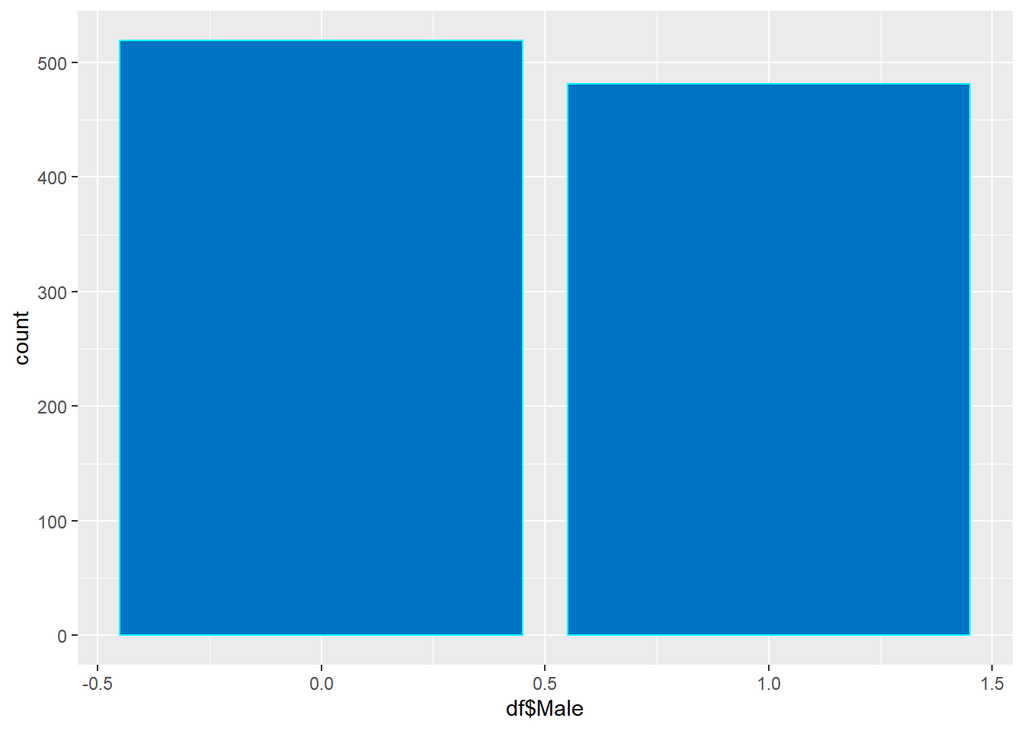

```r
# bargraph showing clicking of ads by gender
ggplot(data = df, aes(x = df$Male)) +  geom_bar(fill = "#0073C2FF", color = 'cyan')
```

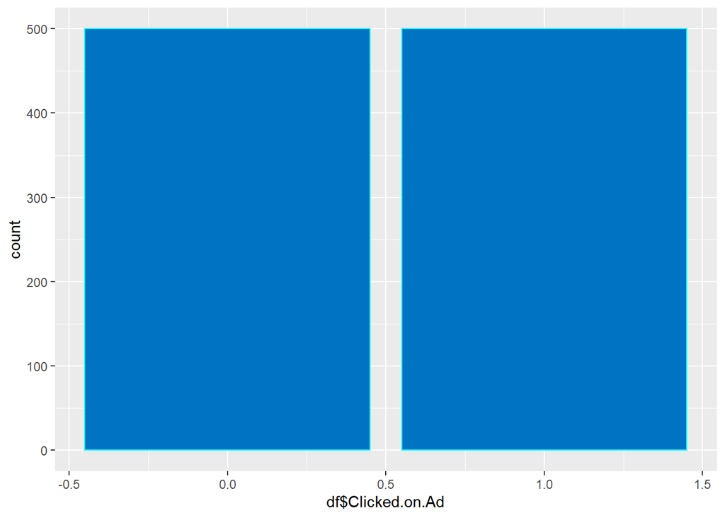

```r
# barplot showing count of how people clicked on ads

ggplot(data = df, aes(x = df$Clicked.on.Ad)) +  geom_bar(fill = "#0073C2FF", color = 'cyan')
```

There was an equal number of individuals who clicked on ad and those who did not.

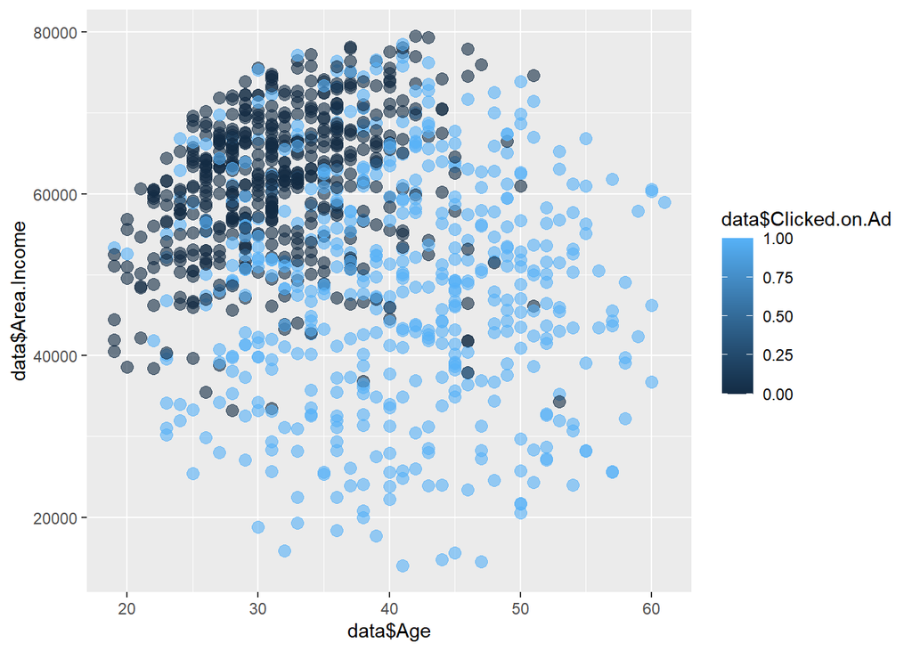

```r
# relationship between income and clicking on ad

#qplot(data=data, x=data$Age,y=data$Area.Income, colour=data$Clicked.on.Ad, #size=I(3),shape=I(16),alpha=0.6, main = "Income vs clicking on ad")

ggplot(data = data) +
    geom_point(aes(x = data$Age, y = data$Area.Income, color = data$Clicked.on.Ad), size = 3, alpha = 0.6)
```

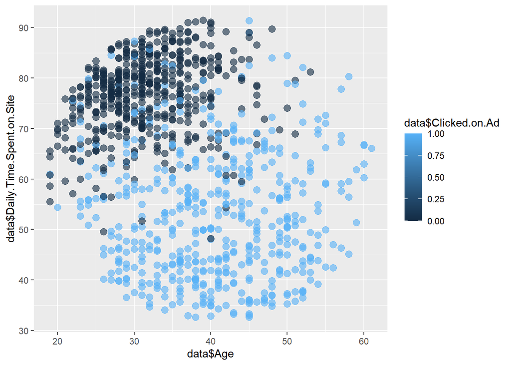

```r
# Scatterplot showing relationship between age, time spent on site and clicking on ads

ggplot(data = data) +
  geom_point(aes(x = data$Age, y = data$Daily.Time.Spent.on.Site, color = data$Clicked.on.Ad), size = 3, alpha = 0.6)
```

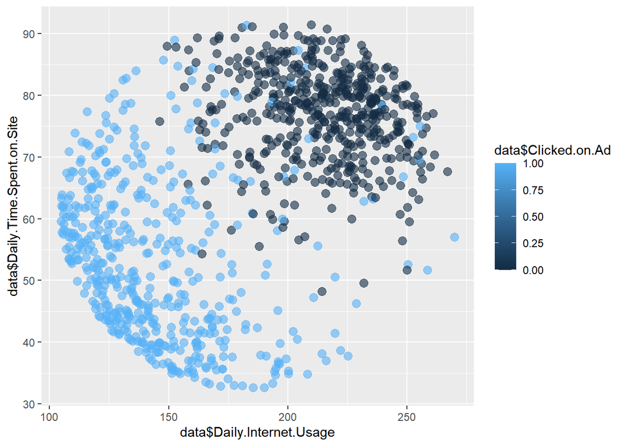

```r
# Scatterplot showing relationship between internet usage, time spent on site and clicking on ads

ggplot(data = data) +
  geom_point(aes(x = data$Daily.Internet.Usage, y = data$Daily.Time.Spent.on.Site, color = data$Clicked.on.Ad), size = 3, alpha = 0.6)
```